# Seattle Airbnb Content-Based Recommendation System

- Dataset Source: https://www.kaggle.com/airbnb/seattle
- Reasons for choosing this dataset:
  - It is a very good dataset for an content-based recommendation because the presence of numerous text columns which describes the Airbnb listing in every area. E.g. "description", "neighborhood", "transit", "host_about"
  - This really suits the context of a Chatbot well because basically, users can just tell us anything about their ideal airbnb and we can ask them very broad questions
  - Will be able to create a very natural conversation experience, unlike mechanical conversations where Chatbot ask specific questions from user and expect specific answers
  - There are also other useful columns such as "review score" which can be really helpful in recommending an Airbnb
  - Furthermore, the dataset comes with a Review dataset which contains 80000+ reviews for all the listings. This opens up other possibilities to our recommendation system such as Sentiment analysis and Topic identification to provide a better user experience with additional features

## Plan

- Using chatbot to first ask for filter columns e.g. budget (price), property_type, room_type)
  - Filter columns will be used to filter out AirBnBs that does not meet the hard requirement
- Then ask what are users' expectations of the AirBnb they want to stay in
  - E.g. host personality, ambience, interior design, location, neighbourhood, ...
- Concatenate the potential description columns to produce a document for each Airbnb listing
- Natural Language processing of the document of each Airbnb
- Based on user's description, insert it into the Airbnb listing dataframe, act as if it is a listing itself
- Generate the TFIDF vector for the whole Airbnb listing dataframe
- Compute the cosine similarity of user description's vector array with all the other listing vector arrays
- Recommend the top 2 similar AirBnb listing to user
- Additional Features:
  - Sentiment Analysis for the reviews dataset to generate a sentiment score for each Airbnb listing
  - Topic Analysis - Identify top 3 bigrams in recommended listings' reviews and output to user with the bigrams in original sample review

```python
# Import necessary libraries
import pandas as pd
import numpy as np
import math
import string
import random
import matplotlib.pyplot as plt
import seaborn as sns

from wordcloud import WordCloud, STOPWORDS
from nltk.tokenize import word_tokenize, wordpunct_tokenize
from nltk.corpus import stopwords, words
from nltk.stem import WordNetLemmatizer

from sklearn.feature_extraction.text import TfidfVectorizer
from sklearn.metrics.pairwise import linear_kernel

from nltk import BigramAssocMeasures, BigramCollocationFinder

import warnings
warnings.filterwarnings('ignore')

%matplotlib inline
```

```python
# Import datasets
airbnbs = pd.read_csv('listings.csv')
reviews = pd.read_csv('reviews.csv')

print(airbnbs.shape)
print(reviews.shape)
```

```
(3818, 92)
(84849, 6)
```

```python
# Get an overview of the Airbnb listing dataset
pd.set_option('display.max_columns', 100)
airbnbs.sample(3)
```

|  | id | listing_url | scrape_id | last_scraped | name | summary | space | description | experiences_offered | neighborhood_overview | notes | transit | thumbnail_url | medium_url | picture_url | xl_picture_url | host_id | host_url | host_name | host_since | host_location | host_about | host_response_time | host_response_rate | host_acceptance_rate | host_is_superhost | host_thumbnail_url | host_picture_url | host_neighbourhood | … |
| --- | --- | --- | --- | --- | --- | --- | --- | --- | --- | --- | --- | --- | --- | --- | --- | --- | --- | --- | --- | --- | --- | --- | --- | --- | --- | --- | --- | --- | --- | --- |
| 2991 | 7934963 | https://www.airbnb.com/rooms/7934963 | 20160104002432 | 2016-01-04 | Ballard Bliss | Private bedroom in a beautiful house located i... | My calendar is always updated. If you see the ... | Private bedroom in a beautiful house located i... | none | • Less than 5 minutes walk to bus stop • 10 mi... | For future guests: If you do not have any revi... | • Less than 5 minutes walk to bus stop (40 loc... | https://a0.muscache.com/ac/pictures/105583002/... | https://a0.muscache.com/im/pictures/105583002/... | https://a0.muscache.com/ac/pictures/105583002/... | https://a0.muscache.com/ac/pictures/105583002/... | 5744697 | https://www.airbnb.com/users/show/5744697 | Farah | 2013-04-03 | Seattle, Washington, United States | Nice to meet you!\r\n I am originally from Ind... | within an hour | 100% | 100% | f | https://a1.muscache.com/ac/users/5744697/profi... | https://a1.muscache.com/ac/users/5744697/profi... | Ballard | … |
| 2122 | 6561379 | https://www.airbnb.com/rooms/6561379 | 20160104002432 | 2016-01-04 | Beacon Hill 2br with Park Views | Right across the street from Jefferson Park in... | This 1953 rambler-style house is a great home ... | Right across the street from Jefferson Park in... | none | The neighborhood is safe with plenty of family... | NaN | You don't need a car to explore the city from ... | https://a2.muscache.com/ac/pictures/99624979/3... | https://a2.muscache.com/im/pictures/99624979/3... | https://a2.muscache.com/ac/pictures/99624979/3... | https://a2.muscache.com/ac/pictures/99624979/3... | 34321359 | https://www.airbnb.com/users/show/34321359 | Colin | 2015-05-26 | Seattle, Washington, United States | NaN | within a few hours | 100% | 100% | f | https://a1.muscache.com/ac/users/34321359/prof... | https://a1.muscache.com/ac/users/34321359/prof... | NaN | … |
| 3422 | 7698721 | https://www.airbnb.com/rooms/7698721 | 20160104002432 | 2016-01-04 | Easy City Access, U.W. Children's | House in a quiet neighborhood. Easy access to ... | Our home is in a quiet neighborhood near the U... | House in a quiet neighborhood. Easy access to ... | none | Our neighborhood is a great place to walk. We'... | NaN | Our home is close to the 30, 75, 71 and 76 bus... | https://a0.muscache.com/ac/pictures/105084050/... | https://a0.muscache.com/im/pictures/105084050/... | https://a0.muscache.com/ac/pictures/105084050/... | https://a0.muscache.com/ac/pictures/105084050/... | 1024728 | https://www.airbnb.com/users/show/1024728 | Barbara | 2011-08-26 | Seattle, Washington, United States | My name is Barbara and I love to travel, so I ... | NaN | NaN | NaN | f | https://a1.muscache.com/ac/users/1024728/profi... | https://a1.muscache.com/ac/users/1024728/profi... | Windermere | … |

- Potential columns for **strict filtering**:
  - price, property_type, room_type
- Potential columns to be used to **generate TFIDF vectors**:
  - description, neighborhood_overview, notes, transit, host_about,

```python
# Explore on strict filter columns
# Check for null values
filter_cols = "property_type, room_type, price".split(", ")
airbnbs[filter_cols].isnull().sum()
```

```
property_type    1
room_type        0
price            0
dtype: int64
```

```python
airbnbs['property_type'].value_counts()
```

```
House              1733
Apartment          1708
Townhouse           118
Condominium          91
Loft                 40
Bed & Breakfast      37
Other                22
Cabin                21
Camper/RV            13
Bungalow             13
Boat                  8
Tent                  5
Treehouse             3
Chalet                2
Dorm                  2
Yurt                  1
Name: property_type, dtype: int64
```

```python
airbnbs['room_type'].value_counts()
```

```
Entire home/apt    2541
Private room       1160
Shared room         117
Name: room_type, dtype: int64
```

```python
# Price is String type. Sample -> E.g. $79.00
# Convert it to float
airbnbs['price'] = airbnbs['price'].apply(lambda x : float(x[1:].replace(",",""))).astype(float)
airbnbs['price'].describe()
```

```
count    3818.000000
mean      127.976166
std        90.250022
min        20.000000
25%        75.000000
50%       100.000000
75%       150.000000
max      1000.000000
Name: price, dtype: float64
```

- Maximum price per night is $1000

```python
# Explore on description columns
desc_cols = "description, neighborhood_overview, notes, transit, host_about".split(", ")
nan_cols = airbnbs[desc_cols].isnull().sum()
nan_cols[nan_cols != 0].sort_values(ascending=False)
```

```
notes                    1606
neighborhood_overview    1032
transit                   934
host_about                859
dtype: int64
```

- Not going to include "notes" column as almost half of it is NaN
- Reading some sample of "notes", mainly consists of unimportant information
  - E.g "Please send me your real email address with yo..." & "The view!"

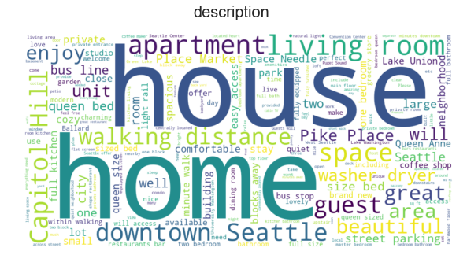

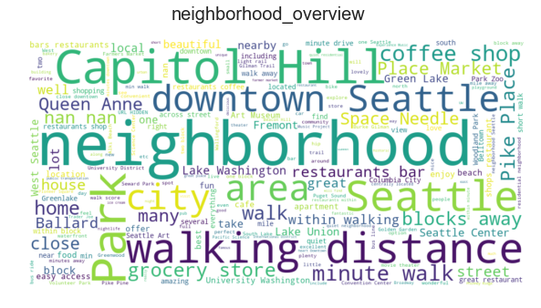

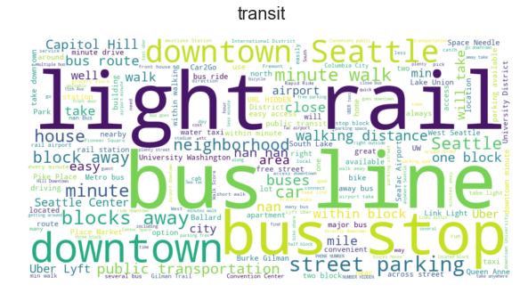

[figure not shown]

```python
desc_cols.remove("notes")

# Visualize some of the important word in each potential column
for col in desc_cols:
    if airbnbs[col].dtype == np.object:
        corpus = " ".join(airbnbs[col].astype(str))
        wordcloud = WordCloud(stopwords=STOPWORDS, background_color='white', width=1000, height=500).generate(corpus)
        fig = plt.figure(figsize=(10,5))
        plt.imshow(wordcloud, interpolation="bilinear")
        fig.suptitle(col, fontsize=20)
        plt.axis("off")
        plt.show()
```

- For each column, we can analyze the **words that appear frequently** to **craft prompt questions in our chatbot**
- The frequent words can also be used as **entities to be picked up by Dialog Flow** and input as user's description
  - E.g. in "description" column, words such as "queen size", "full kitchen", "Capitol Hill" appears quite often
- Possible questions the chatbot can ask the user:
  - "What do you expect in your room?"
  - "Do you want to cook during your stay there?"
  - "Where are you planning to go in Seattle?"

```python
# Explore on "review_scores_rating" column as it might be a good feature to consider when recommending
airbnbs['review_scores_rating'].isnull().sum()
```

```
647
```

- There are quite a lot of listings without reviews scores.
- If they are recommended by the chat bot, users will not be able to make an informed decision and affect the user experience

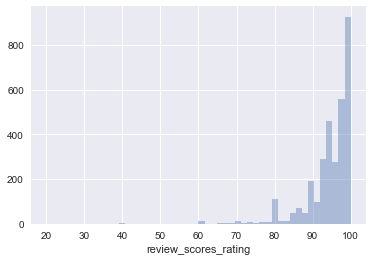

```python
sns.distplot(airbnbs['review_scores_rating'].dropna(), kde=False)
```

- Review score on the AirBnB listings is **highly skewed left**
- Many listings with very high rating and very few with low rating
  - Hosts can artifically make their rating higher by giving his or her own listing high scores
  - Not really helpful in helping user to decide
- **Do sentiment analysis on the reviews** and assign **a mean score to each listing**.
- It would be a much **better reflection of the listing** rather than the skewed review score

## Additional Feature: Sentiment Analysis on Reviews Dataset

- Using **VADER library** to generate a sentiment score for each review
- Group by listing_id and calculate a mean review sentiment score for each listing
- **Please refer to the "Review Sentiment Analysis-Additional" python notebook for details**
  - The generated "listings_review_sent_score.csv" dataset from the notebook is imported below for further recommendation

```python
# load the listings dataset with review sentiment score generated for each listing
# Which is then used to recommendation
airbnbs = pd.read_csv("listings_review_sent_score.csv")
```

```python
# Fill in missing values for interest columns

# The listing that is missing "property_type" is actually an apartment after reading description
airbnbs[airbnbs['property_type'].isnull()]
airbnbs['property_type'].fillna("Apartment", inplace=True)

# Filling in missing values for desc_cols
for col in desc_cols:
    if airbnbs[col].dtype == np.object:
        airbnbs[col].fillna("", inplace=True)
    if airbnbs[col].dtype == np.float64:
        airbnbs[col].fillna(airbnbs[col].median(), inplace=True)
```

```python
# Price is String type. Convert it to float
airbnbs['price'] = airbnbs['price'].apply(lambda x : float(x[1:].replace(",",""))).astype(float)

# Reduce the property_type to lesser categories
def parse_property_type(property):
    property_map = {"House" : "House",
           "Apartment" : "Apartment",
            "Townhouse" : "House",
           "Condominium" : "Apartment",
            "Loft" : "Apartment",
            "Bed & Breakfast" : "House",
            "Other" : "Exotic",
            "Cabin" : "Exotic",
            "Camper/RV": "Exotic",
            "Bungalow" : "House",
           "Boat" : "Exotic",
           "Tent" : "Exotic",
           "Treehouse" : "Exotic",
           "Chalet" : "Exotic",
           "Dorm" : "Exotic",
           "Yurt" : "Exotic"}
    return property_map[property]

airbnbs['property_type'] = airbnbs['property_type'].map(parse_property_type)
```

```python
# Sample user input sent from DialogFlow
user_input = [ "200", # Budget; maximum price acceptable per night
              "Apartment", # property-type = "Aparment" OR "House" OR "Exotic"
              "Private room", # room-type = "Entire home/apt" OR "Private room" OR "Shared room"
              "I want an clean and mordern finished apartment. I hope my room will have a queen-size bed. It would be great if the house has clean bathrooms.",
              "It is better to have grocery stores and some place where I can buy coffee around the apartment",
              "During my stay, I would like to visit Capitol Hill and Space Needle. My prefered mode of transportation is train and bus.",
              "I hope the host will be friendly, and preferably a young working profession couple.",
              ]
```

```python
# Filter Airbnb listings from the dataset that does not meet the requirement based on user's input for filter columns
# Not compulsory for user to have price, room_type, property_type requirement
def filter_listing(dataset, price=1001, property_type=None, room_type=None):
    if room_type == None and property_type == None:
        dataset = dataset.loc[dataset['price'] < price]
    elif property_type == None:
        dataset = dataset.loc[(dataset['price'] < price) & (dataset['room_type'] == room_type)]
    elif room_type == None:
        dataset = dataset.loc[(dataset['price'] < price) & (dataset['property_type'] == property_type)]
    else:
        dataset = dataset.loc[(dataset['price'] < price) & (dataset['property_type'] == property_type) & (dataset['room_type'] == room_type)]
    return dataset

listing = filter_listing(airbnbs, price=float(user_input[0]), property_type=user_input[1], room_type=user_input[2])
listing.reset_index(drop=True, inplace=True)
listing.shape
```

```
(249, 93)
```

```python
# Insert user's input as one of the listing
desc_listing = listing[desc_cols]
desc_listing.iloc[-1] = user_input[3:]
desc_listing.tail(1)
```

|  | description | neighborhood_overview | transit | host_about |
| --- | --- | --- | --- | --- |
| 248 | I want an clean and mordern finished apartment... | It is better to have grocery stores and some p... | During my stay, I would like to visit Capitol ... | I hope the host will be friendly, and preferab... |

```python
# Concatenate all potential columns together to generate TF-IDF matrix for each AirBnb listing
desc_listing['overall'] = desc_listing.astype(str).apply(lambda x : " ".join(x), axis=1)
desc_listing['overall'].sample(3)
```

```
59     Private room in attic apartment with northern ...
34     Private - Queen bed with mattress Fan Study ta...
226    The space for rent is a minimalist clean priva...
Name: overall, dtype: object
```

## Term Frequency-Inverse Document Frequency (TF-IDF) Vectors

- TF-IDF vectors reflect a word's importance to an document, adjusting its importance by taking into account the number of documents containing that word
  - The importance of a word = TF * IDF
- Term Frequency (TF) is the relative frequency of a word in a document
  - Calculated as (The Word's instances)/(Total Number of Words)
- Inverse Document Frequence is the relative count of documents containing that word
  - Calculated as log(Number of documents/Number of document with the word)
- When a word appears more time in a document -> TF increases -> TF * IDF will increase -> more important
- When a word appears in many documents -> (Number of documents/Number of document with the word) will decrease -> IDF decreases -> TF * IDF decreases -> less important
- The sklearn.feature_extraction.text.TfidfVectorizer will compute the TF-IDF vectors for the Airbnb listing dataset
  - TfidfVectorizer will output an csr_matrix; similar to numpy array but does not record words that does not appear in its document
  - Each row in the csr_matrix is the document of each Airbnb listing (potentional desc columns concatenated)
  - Each column is the word that appears in the document with its importance (TF * IDF)
- Reference:
  - https://www.kaggle.com/ibtesama/getting-started-with-a-movie-recommendation-system
  - https://www.kaggle.com/rdaldian/airbnb-content-based-recommendation-system/data
  - https://www.datacamp.com/courses/unsupervised-learning-in-python

```python
# Preprocessing function for each listing's doc
# Not used as TfidfVectorizer's default preprocessing and tokenizer is good enough
def preprocessing(doc):
    # Lowercasing
    doc = doc.lower()
    # Tokenize the document
    tokens = word_tokenize(doc)
    # Remove stopwords
    tokens = [token for token in tokens if token not in stopwords.words('english')]
    # Lemmatization
    wordnet_lemmatizer = WordNetLemmatizer()
    lemmed_token = [wordnet_lemmatizer.lemmatize(token) for token in result]
    return lemmed_token

tfidf = TfidfVectorizer(analyzer='word', stop_words='english', ngram_range=(1,2), min_df=1)
# Default tokenizer = default regexp selects tokens of 2 or more alphanumeric characters
# Punctuation is completely ignored and always treated as a token separator
# Ideal for our case as we just want the keywords in Airbnb description columns

# analyzer='word' -> extract out words as columns
# ngram_range=(1,2) -> (1,2) for one-word and two-word tokens, (1,1) for outputting only one-word tokens and (2, 3) for two-word and three-word tokens
# stop_words='english' -> Remove stopwords in english
# min_df=0 -> Do not ignore words that have a term frequency that is below 1
```

```python
listing_matrix = tfidf.fit_transform(desc_listing['overall'])
listing_matrix.shape
```

```
(249, 30322)
```

- We can see that 30322 words are used to described the 249 possible listings after filtering

```python
# Visualize the TFIDF Vectors
words = tfidf.get_feature_names() # Returns the ngrams [word(s)] extracted
df = pd.DataFrame(listing_matrix.toarray(), index=desc_listing.index, columns=words)
df.sample(1)
```

|  | 00 | 00 cleaning | 00 lots | 00 pm | 00 public | 00 quarters | 00 total | 0r | 0r 35 | 10 | 10 00 | 10 11 | 10 12 | 10 15 | 10 15th | 10 20 | 10 block | 10 bus | 10 buses | 10 cab | 10 languages | 10 lot | 10 min | 10 mins | 10 minute | 10 minutes | 10 night | 10 nighttime | 10 pike | … |
| --- | --- | --- | --- | --- | --- | --- | --- | --- | --- | --- | --- | --- | --- | --- | --- | --- | --- | --- | --- | --- | --- | --- | --- | --- | --- | --- | --- | --- | --- | --- |
| 14 | 0.0 | 0.0 | 0.0 | 0.0 | 0.0 | 0.0 | 0.0 | 0.054525 | 0.054525 | 0.043347 | 0.0 | 0.0 | 0.0 | 0.0 | 0.0 | 0.0 | 0.0 | 0.0 | 0.0 | 0.0 | 0.0 | 0.0 | 0.0 | 0.0 | 0.031676 | 0.033969 | 0.0 | 0.0 | 0.0 | … |

1 rows × 30322 columns

- This is a sample TFIDF vector for an Airbnb listing
- All words in all listings's document are taken into account
- Only words in this listing will have its TF * IDF calculated, otherwise will have a value of 0

## Cosine-similarity

- After generating the TF-IDF vectors of every Airbnb Listing, this is equvalient to representing each listing in a multi-dimensional space with each dimension being a word.
- In this multi-dimensional space, each listing is at different point, determinied by its words' TF * IDF values
  - This is also known as word vectors
- The similarity of two listings' vectors can be computed by consine-similarity; cos(c) = v1*v2 / v1.v2
  - c is actually the angle between the 2 vectors.
  - cos(c) = 1 -> Vector in same direction -> identical
  - cos(c) = 0 -> Vector perpendicular -> very different
- We will use linear_kernel to compute the similarity between listings' vectors
- Reference:
  - https://www.datacamp.com/courses/natural-language-processing-fundamentals-in-python
  - https://www.datacamp.com/courses/building-chatbots-in-python
  - My own Maths knowledge on Vectors

```python
# Generate the cosine similarity matrix for each listing against every other listing
cosine_sim = linear_kernel(listing_matrix, listing_matrix)
```

```python
# Retrieve the similarity scores for user's input which is the last listing
similarity_score = list(enumerate(cosine_sim[-1]))

# Sort the scores with AirBnBs that is the most similar
similarity_score = sorted(similarity_score, key=lambda x: x[1], reverse=True)

# Get the 2 most similar AirBnB's index
sim_index = [listing[0] for listing in similarity_score[1:3]] #Ignore index 0 as it is user's input

# Retrieve the top 10 AirBnB
recommendation = listing.iloc[sim_index][['id','name', 'price'] + ['review_senti_score', 'review_scores_rating', 'reviews_per_month', 'host_url'] + filter_cols +  desc_cols ]
recommendation.sort_values('review_senti_score', ascending=False, inplace=True)
recommendation
```

|  | id | name | price | review_senti_score | review_scores_rating | reviews_per_month | host_url | property_type | room_type | price | description | neighborhood_overview | transit | host_about |
| --- | --- | --- | --- | --- | --- | --- | --- | --- | --- | --- | --- | --- | --- | --- |
| 61 | 4238106 | Sweet City Space | 75.0 | 0.989800 | 100.0 | 1.5 | https://www.airbnb.com/users/show/2205509 | Apartment | Private room | 75.0 | Bright and happy private bedroom in an apartme... | Location location! We are a quick walk to Capi... | Easy access to Seattle's bus system, and 1.2 m... | I like to ride my bicycle.. a lot. Actually, I... |
| 232 | 1818768 | Comfortable Bedroom in Capitol Hill | 70.0 | 0.932494 | 95.0 | 2.1 | https://www.airbnb.com/users/show/5589030 | Apartment | Private room | 70.0 | Our extra bedroom is perfect for your Seattle ... | Capitol Hill is the perfect place to experienc... | Public transportation is only a minute's walk ... | We're newlyweds and young professionals in the... |

- As we can see our **recommendations's "description", "neighborhood_overview", "transit", "host_about" is similar to our user's description of his or her dream AirBnB**
- Besides that, both the **"review_scores_rating"** and the **"review_senti_score"** of the 1st listing outscored the 2nd recommended listing, meaning **the first 1 is probably a better choice.**
- Possible JSON to be returned to Dialog Flow:

  ```
  {
        'recommendations':[
            {
                'name':'Sweet City Space',
                'price':'75',
                'review_senti_score':'0.989800',
                'review scores_rating':'100.0',
                'reviews_per_month':'1.5',
                'host_url':'https://www.airbnb.com/users/show/2205509'
            },
            {
                'name':'Comfortable Bedroom in Capitol Hill',
                'price':'70',
                'review_senti_score':'0.932494',
                'review scores_rating':'95.0',
                'reviews_per_month':'2.10',
                'host_url':'https://www.airbnb.com/users/show/5589030'
            }
        ]
    }
  ```

- Only these columns will be returned as all other information can be checked out at the host_url
  - Can actually checkout the host_url - They are active URLs

## Addition Feature: Topic Analysis - Identify Keywords in Listing's Reviews

```python
# Import the processed review dataset from "Review Sentiment Analysis" notebook
# It has NaN filled and non-english comments removed. So no need to process here again
reviews = pd.read_csv("reviews_processed.csv")
```

```python
# Filter out reviews for the recommended listings
reviews = reviews[(reviews['listing_id'] == recommendation['id'].values[0]) | (reviews['listing_id'] == recommendation['id'].values[1])]
print("Number of reviews for recommended listings: {}".format(reviews.shape[0]))

# Group the reviews by their listing_id and join all comments of each listing into a doc
listing_reviews = reviews.groupby(['listing_id'])['comments'].apply(lambda x: " ".join(x))
```

```
Number of reviews for recommended listings: 35
```

```python
# Tokenize the doc for each listing
def tokenize(doc):
    tokens = word_tokenize(doc)
    # Remove punctuations
    tokens = [token for token in tokens if token not in string.punctuation]
    # word_tokenize will tokenize contractions. E.g. "didn't" -> ["did", "n't"], "Sally's" -> ["Sally", "'s"]
    # Do not want that to happen as they will always co-occur
    # Will affect the accuracy of top bigrams identified
    result = []
    for i, token in enumerate(tokens):
        if token[0] == "'" or token == "n't":
            result[-1] = result[-1] + token
        else:
            result.append(token)
    return(result)

listing_reviews = listing_reviews.map(tokenize)
listing_reviews
```

```
listing_id
1818768    [Daniel, and, Lizzy, were, amazing, hosts, Not...
4238106    [Our, stay, with, Grace, was, super, good, She...
Name: comments, dtype: object
```

```python
# Identify the top 3 bigrams for each listing
def bigramify(doc):
    bigram_measures = BigramAssocMeasures()
    finder = BigramCollocationFinder.from_words(doc)
    # If the bigram didn't appear more than 3 times, we will not consider them
    finder.apply_freq_filter(3)
    # Return the top 3 bigrams
    return finder.nbest(bigram_measures.pmi, 3)

listing_bigrams = listing_reviews.map(bigramify)
listing_bigrams
```

```
listing_id
1818768    [(Capitol, Hill), (parking, pass), (minute, wa...
4238106                  [(out, of), (we, were), (of, town)]
Name: comments, dtype: object
```

```python
# Return the top bigrams with the reviews that they appear in
# Easier for user to understand the context
def sample_reviews(listing_id):
    # Retrieve the bigrams for the recommended listing
    bigrams = listing_bigrams[listing_id]
    # Retrieve all the reviews for the recommended listing
    review_texts = reviews[reviews['listing_id'] == listing_id]['comments'].values
    sample_reviews = []
    for bigram in bigrams:
        # Filter out the reviews that contain the bigrams
        comb_bigram = " ".join(bigram)
        potential_reviews = list(filter(lambda review : comb_bigram in review, review_texts))
        # Randomly chose a review that contain the bigram to be displayed
        sample_review = random.choice(potential_reviews)
        # Remove some unwanted characters
        sample_review = sample_review.replace("\n","").replace("\r","")
        # Display the review with bigrams highlighted
        sample_review = sample_review.replace(comb_bigram, "****" + comb_bigram + "****")
        # Display some characters before and after the bigram
        index = sample_review.index(comb_bigram)
        sample_text = "..." + sample_review[index-50 : index+50] + "..."
        sample_reviews.append(sample_text)
    return sample_reviews

sample_reviews(recommendation['id'].values[0])
```

```
['...y, Jared was away during our trip. Grace went ****out of**** her way to give us peace and privacy bu...',
 '...el of Seattle! The neighborhood was great and ****we were**** never worried about our car. The apart...',
 '... I got into their place okay as they were out ****of town**** on the first few days I was there and ...']
```

```python
sample_reviews(recommendation['id'].values[1])
```

```
['... walking distance to all of the cool spots in ****Capitol Hill**** and a half hour walk to Pike Plac...',
 "... coffee shops. If you're driving, they have a ****parking pass**** that'll let you park for free on ...",
 "...ood was great to walk around and only a 20-25 ****minute walk**** to Pike Place. The bed wasn't as c..."]
```

- Not bad! Each bigrams identified for each recommended listing highlights a prominent feature that are common across many of the listing's reviews
  - For example, the 1st listing's host are often out of town. So user can expect peace and privacy
- Definitely helpful for customers to make an more informative choice